# Explore and Summarize Data

Andrew Marksberry

4/27/2021

# Univariate Plots Section

```
## 'data.frame':    4898 obs. of  12 variables:
##  $ fixed.acidity       : num  7 6.3 8.1 7.2 7.2 8.1 6.2 7 6.3 8.1 ...
##  $ volatile.acidity    : num  0.27 0.3 0.28 0.23 0.23 0.28 0.32 0.27 0.3 0.22 ...
##  $ citric.acid         : num  0.36 0.34 0.4 0.32 0.32 0.4 0.16 0.36 0.34 0.43 ...
##  $ residual.sugar      : num  20.7 1.6 6.9 8.5 8.5 6.9 7 20.7 1.6 1.5 ...
##  $ chlorides           : num  0.045 0.049 0.05 0.058 0.058 0.05 0.045 0.045 0.049 0.044 ...
##  $ free.sulfur.dioxide : num  45 14 30 47 47 30 30 45 14 28 ...
##  $ total.sulfur.dioxide: num  170 132 97 186 186 97 136 170 132 129 ...
##  $ density             : num  1.001 0.994 0.995 0.996 0.996 ...
##  $ pH                  : num  3 3.3 3.26 3.19 3.19 3.26 3.18 3 3.3 3.22 ...
##  $ sulphates           : num  0.45 0.49 0.44 0.4 0.4 0.44 0.47 0.45 0.49 0.45 ...
##  $ alcohol             : num  8.8 9.5 10.1 9.9 9.9 10.1 9.6 8.8 9.5 11 ...
##  $ quality             : int  6 6 6 6 6 6 6 6 6 6 ...
```

The dataset consist of 12 variables and 4898 observations.

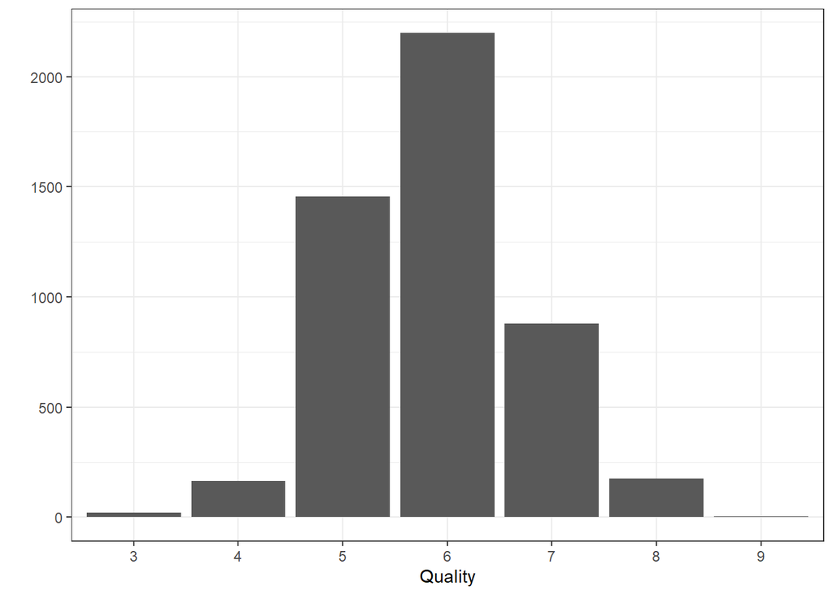

```
##    Min. 1st Qu.  Median    Mean 3rd Qu.    Max.
##   3.000   5.000   6.000   5.878   6.000   9.000
```

White wine quality is normally distributed and concentrated around 5 and 6.

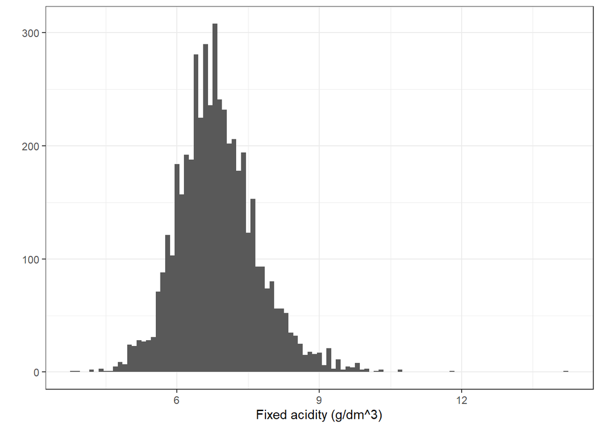

```
##    Min. 1st Qu.  Median    Mean 3rd Qu.    Max.
##   3.800   6.300   6.800   6.855   7.300  14.200
```

The distribution of fixed acidity is right skewed, and concentrated around 6.8

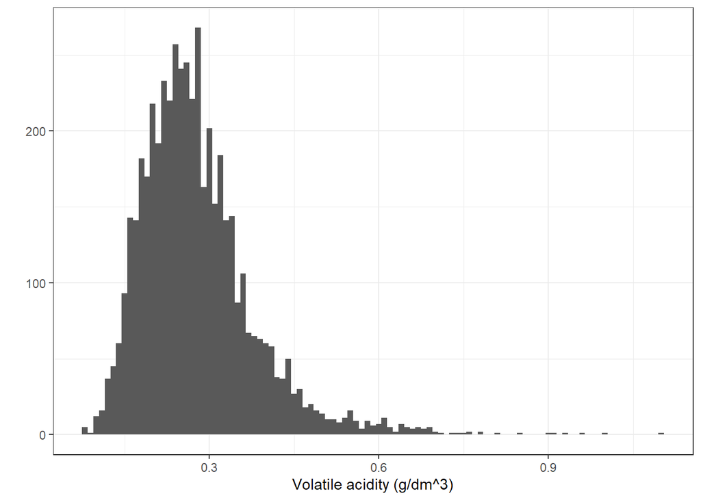

```
##    Min. 1st Qu.  Median    Mean 3rd Qu.    Max.
##  0.0800  0.2100  0.2600  0.2782  0.3200  1.1000
```

The distribution of volatile acidity is also right skewed and concentrated around .26.

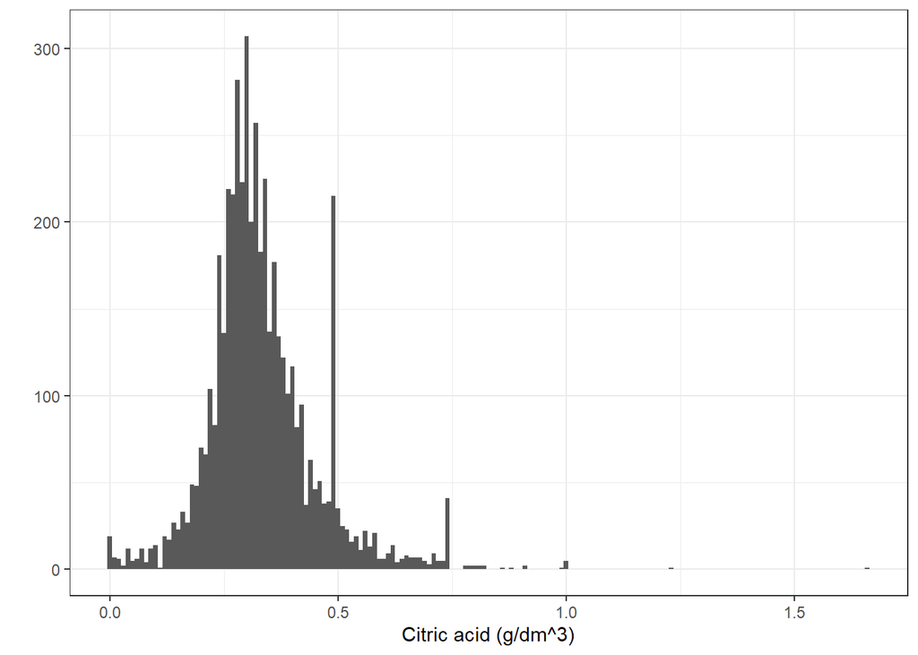

```
##    Min. 1st Qu.  Median    Mean 3rd Qu.    Max.
##  0.0000  0.2700  0.3200  0.3342  0.3900  1.6600
```

The distribution of citric acid is normal and concentrated around .32 and the data contains a few outliers.

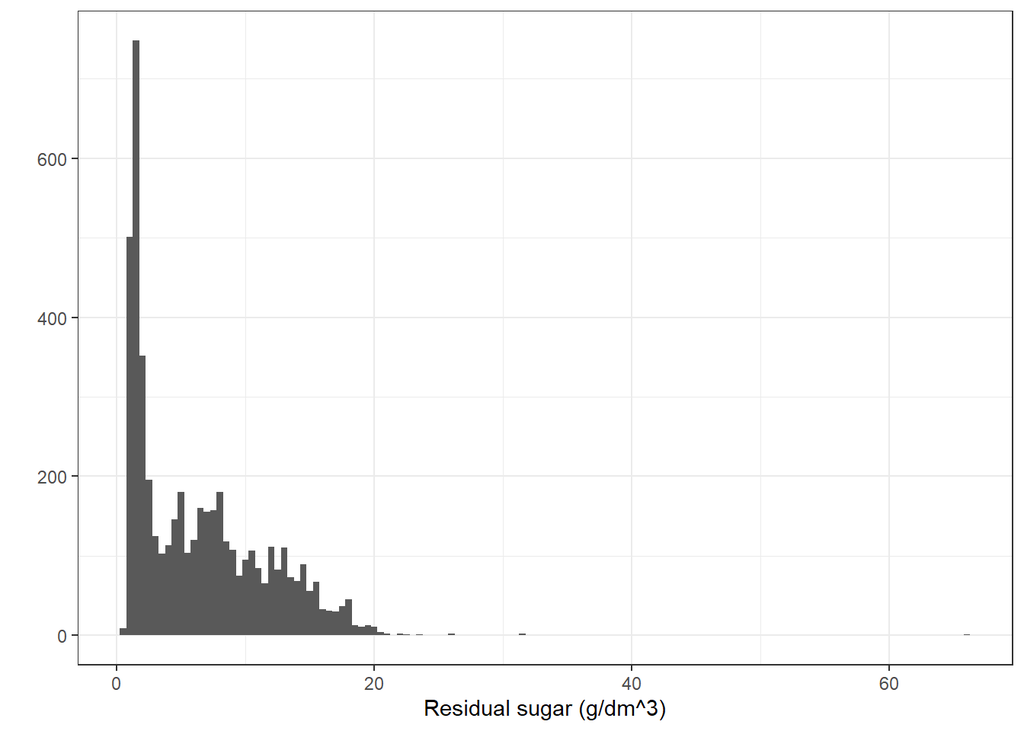

```
##    Min. 1st Qu.  Median    Mean 3rd Qu.    Max.
##   0.600   1.700   5.200   6.391   9.900  65.800
```

The distribution of residual sugar is right skewed.

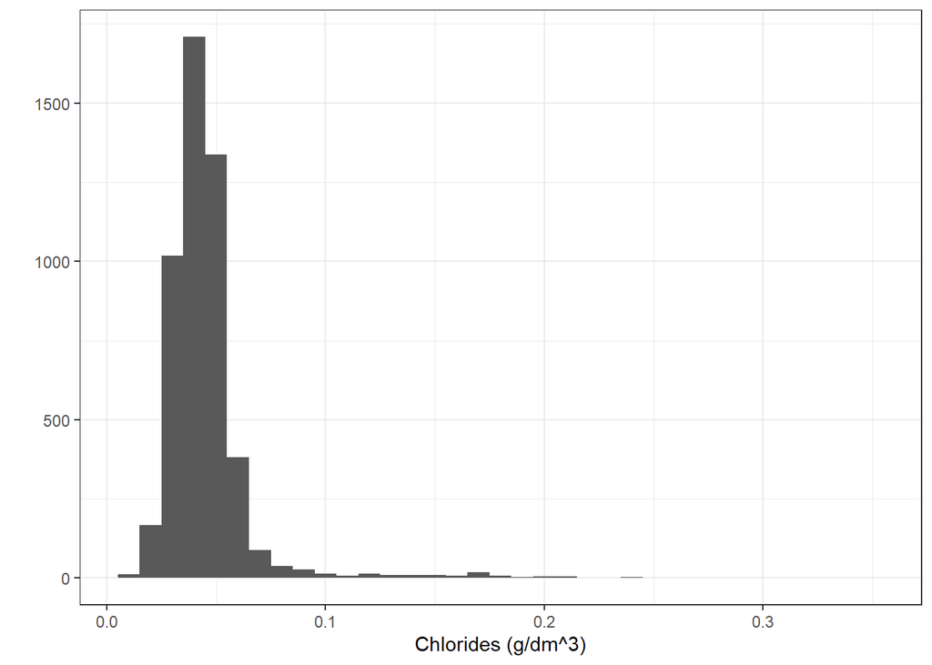

```
##    Min. 1st Qu.  Median    Mean 3rd Qu.    Max.
## 0.00900 0.03600 0.04300 0.04577 0.05000 0.34600
```

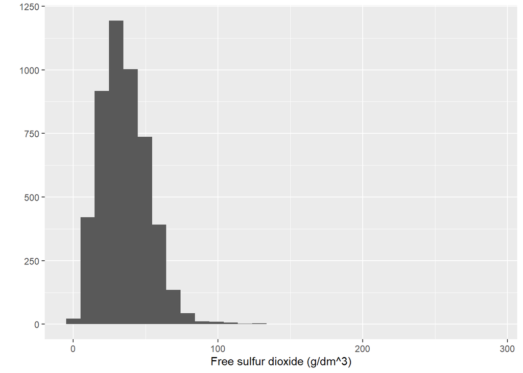

```
##    Min. 1st Qu.  Median    Mean 3rd Qu.    Max.
##    2.00   23.00   34.00   35.31   46.00  289.00
```

The distribution of free sulfur dioxide is normal.

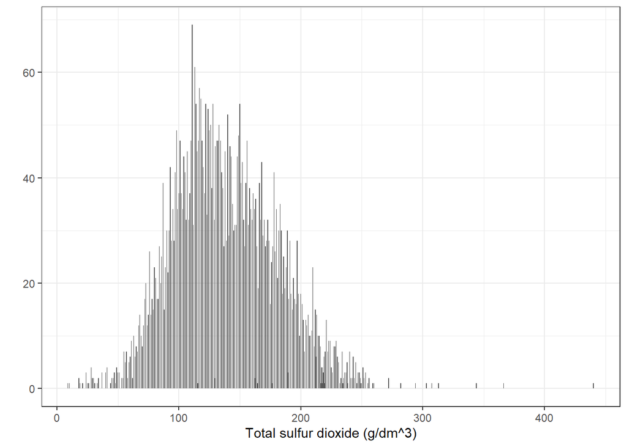

```
##    Min. 1st Qu.  Median    Mean 3rd Qu.    Max.
##     9.0   108.0   134.0   138.4   167.0   440.0
```

The distribution of total sulfur dioxide seems to be unclear whether it is bimodel or unimodel, right skewed or normal.

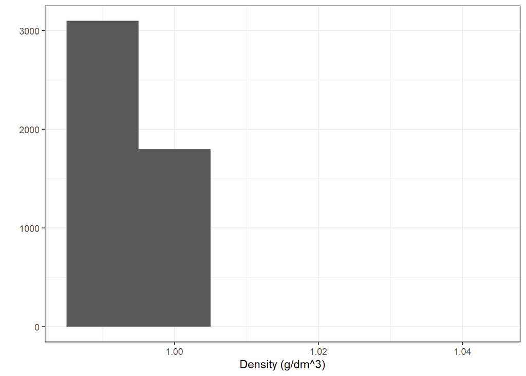

```
##    Min. 1st Qu.  Median    Mean 3rd Qu.    Max.
##  0.9871  0.9917  0.9937  0.9940  0.9961  1.0390
```

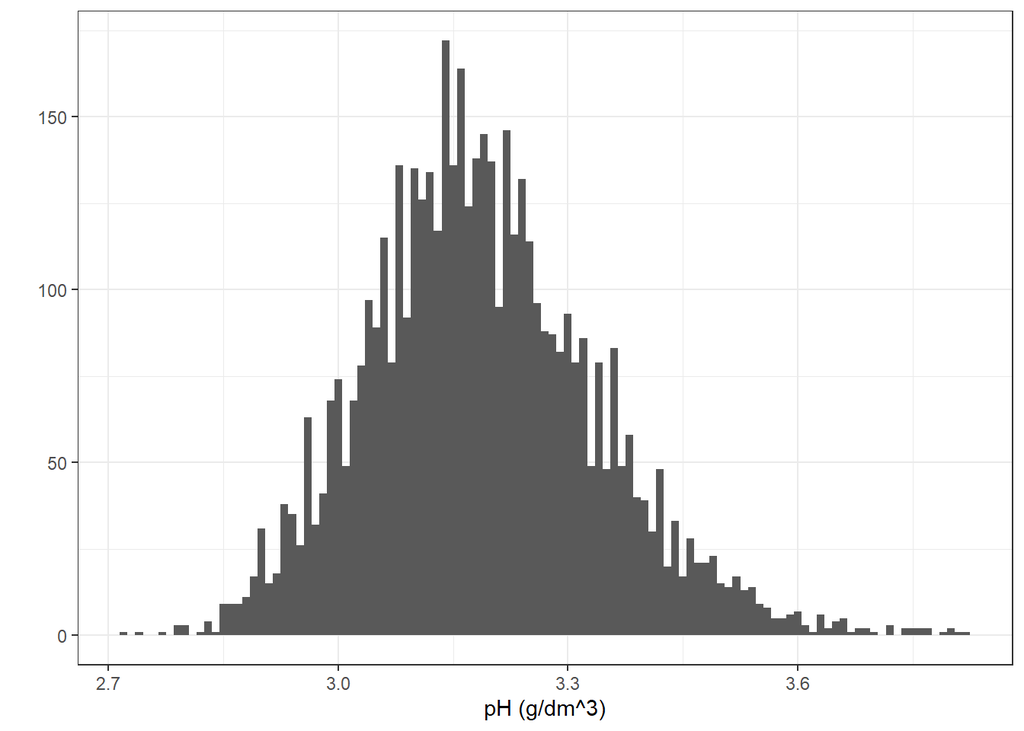

```
##    Min. 1st Qu.  Median    Mean 3rd Qu.    Max.
##   2.720   3.090   3.180   3.188   3.280   3.820
```

The distribution of pH is normal and is concentrated around 3.1

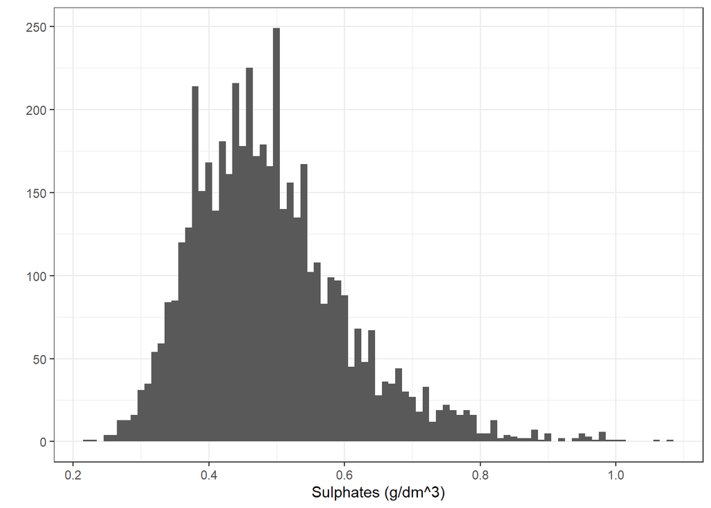

```
##    Min. 1st Qu.  Median    Mean 3rd Qu.    Max.
##  0.2200  0.4100  0.4700  0.4898  0.5500  1.0800
```

The distribution of sulphates is normal and concentrated around .5

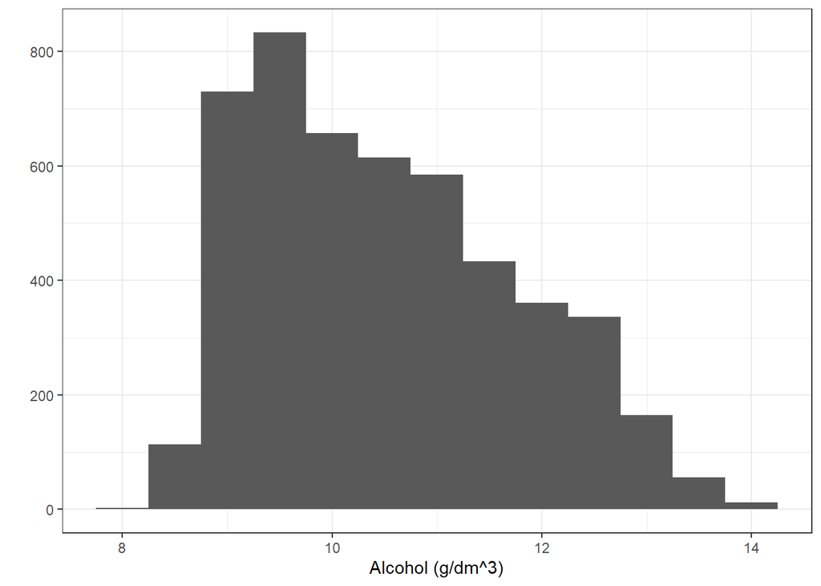

```
##    Min. 1st Qu.  Median    Mean 3rd Qu.    Max.
##    8.00    9.50   10.40   10.51   11.40   14.20
```

The distribution of alcohol is right skewed and is concentrated around 9.5

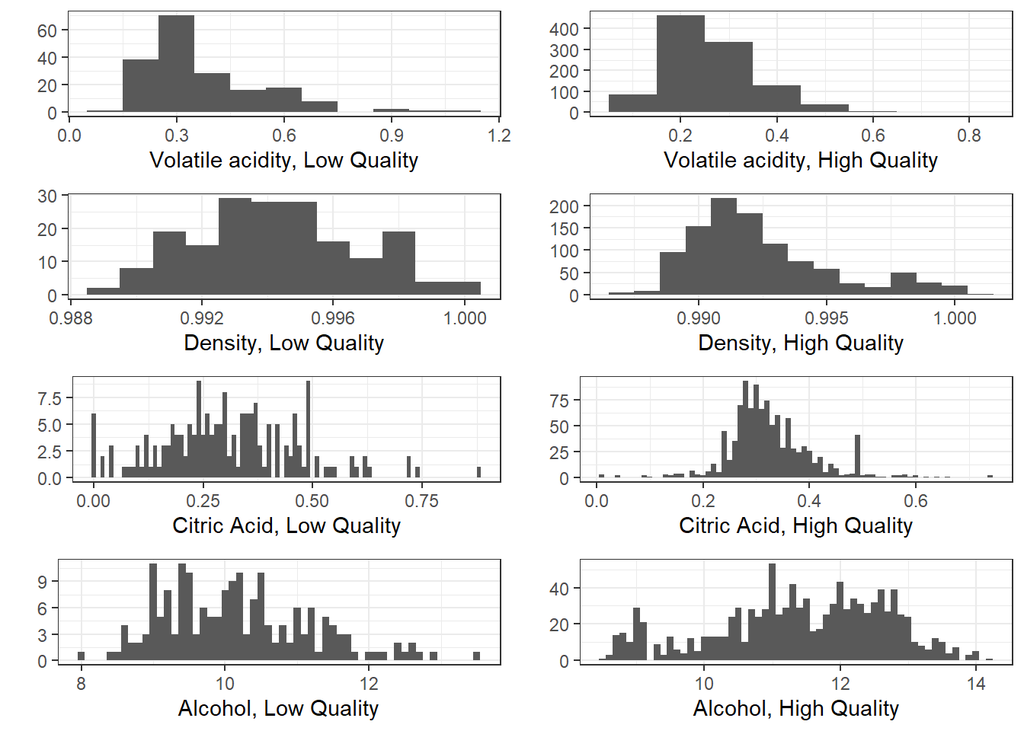

# Univariate Analysis

### What is/are the main feature(s) of interest in your dataset?

My main feature of interest is the wine quality and if there is a connection between the quality and some or all of the collected items.

### What other features in the dataset do you think will help support your investigation into your feature(s) of interest?

I beleive that alcohol, acidity, and residual.sugar will have a relationship to perceived quality.

### Did you create any new variables from existing variables in the dataset?

I created a variable called quality.level that will divide the quality into categories or low, average, and high. This will make dividing up the data by quality easier.

### Of the features you investigated, were there any unusual distributions? Did you perform any operations on the data to tidy, adjust, or change the form of the data? If so, why did you do this?

The citric acid contained some unusual distributions. The data was already clean so no modifications or cleaning was necessary.

# Bivariate Plots Section

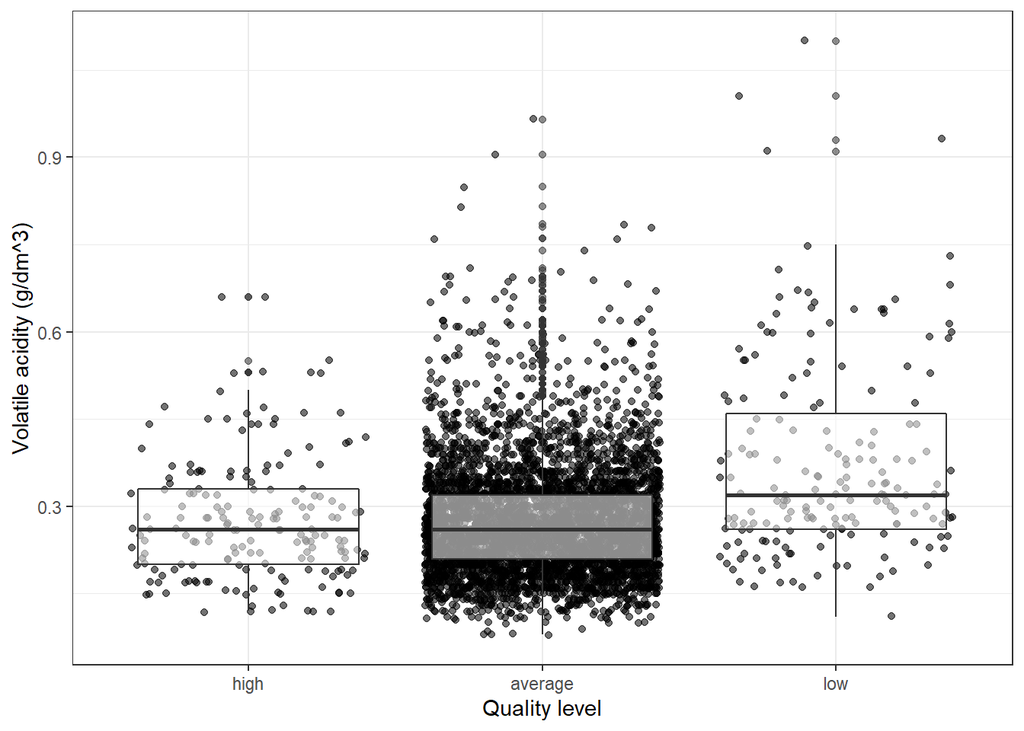

The graph shows that the high and average quality wines have lower volatile acidty than the lower rated wines.

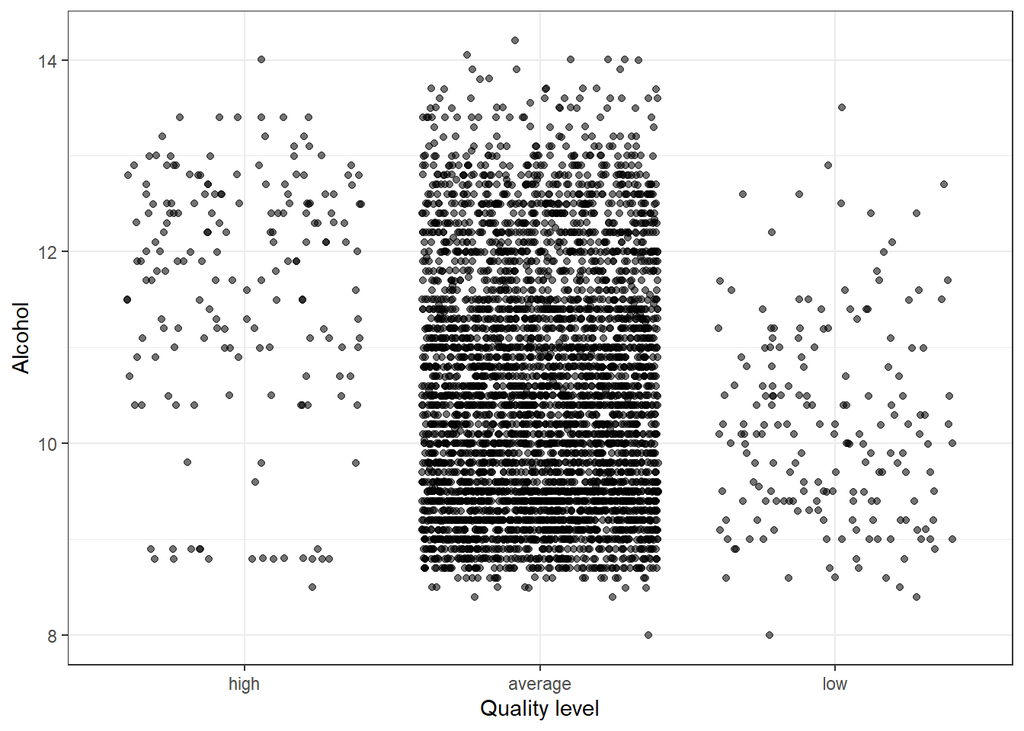

```
##
##  Pearson's product-moment correlation
##
## data:  white_Wine_data$quality and white_Wine_data$alcohol
## t = 33.858, df = 4896, p-value < 2.2e-16
## alternative hypothesis: true correlation is not equal to 0
## 95 percent confidence interval:
##  0.4126015 0.4579941
## sample estimates:
##       cor
## 0.4355747
```

With the correlation coefficient of 0.435, the graph shows a positive relationship between alcohol and quality level. Average quality and low quality wines have their percent alcohol contents concentrated around 10 whereas high quality wines have their percent alcohol contents concentrated around 12.

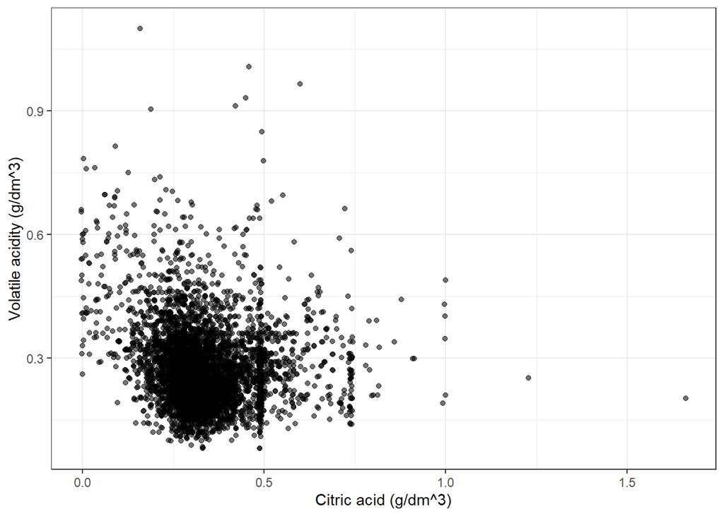

```
##
##  Pearson's product-moment correlation
##
## data:  white_Wine_data$citric.acid and white_Wine_data$volatile.acidity
## t = -10.578, df = 4896, p-value < 2.2e-16
## alternative hypothesis: true correlation is not equal to 0
## 95 percent confidence interval:
##  -0.1767384 -0.1219760
## sample estimates:
##        cor
## -0.1494718
```

There is a negative correlation between citric acid and volatile acidity.

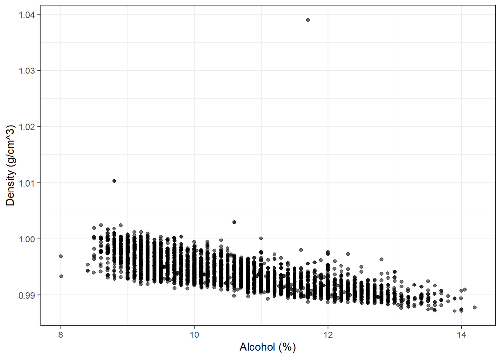

```
##
##  Pearson's product-moment correlation
##
## data:  white_Wine_data$alcohol and white_Wine_data$density
## t = -87.255, df = 4896, p-value < 2.2e-16
## alternative hypothesis: true correlation is not equal to 0
## 95 percent confidence interval:
##  -0.7908646 -0.7689315
## sample estimates:
##        cor
## -0.7801376
```

The correlation coefficient is -0.7, this shows that as the alcohol content increases the density decreases. # Bivariate Analysis

### Talk about some of the relationships you observed in this part of the investigation. How did the feature(s) of interest vary with other features in the dataset?

I observed a negative relationship between citric acid and volatile acidity, and a positive coorelation between quality level and alcohol.

### Did you observe any interesting relationships between the other features (not the main feature(s) of interest)?

Yes, I observed that as alcohol content increases the density decreases.

# Multivariate Plots Section

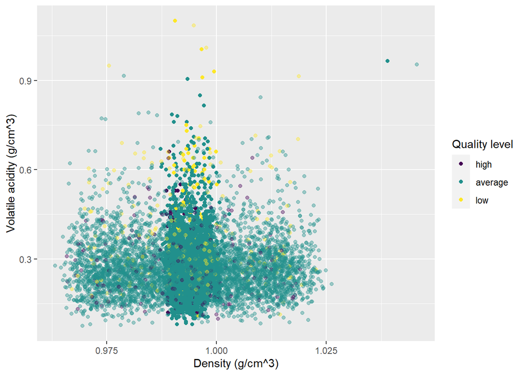

The densities of the high quality wines are concentrated between .99 and 1.

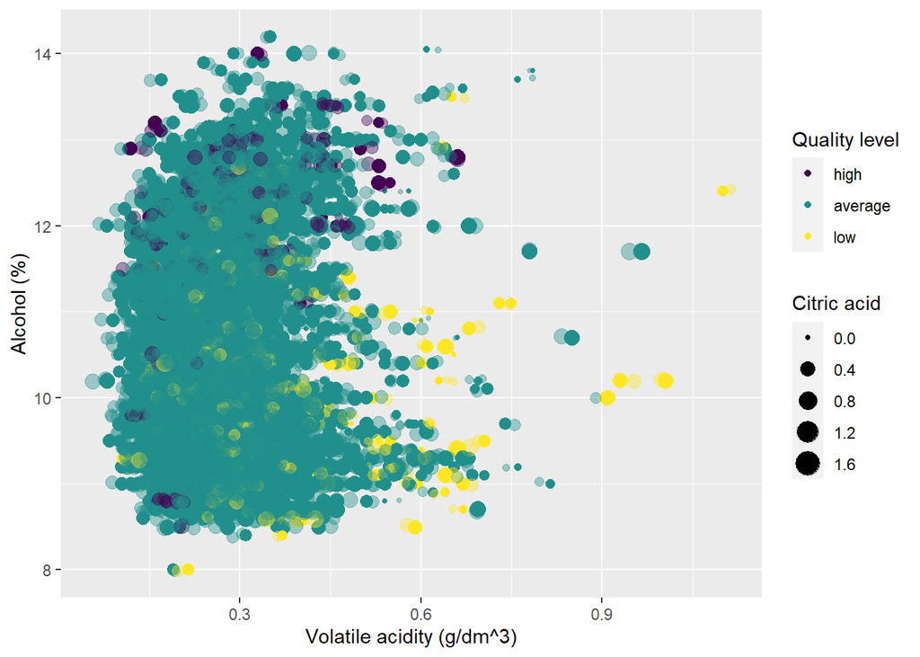

```
## [1] "Percent alcohol contents by quality level:"
```

```
## # A tibble: 3 x 3
##   quality.level  mean    sd
##   <ord>         <dbl> <dbl>
## 1 high           11.7  1.27
## 2 average        10.5  1.21
## 3 low            10.2  1.03
```

```
## [1] "Volatile acidities by quality level:"
```

```
## # A tibble: 3 x 3
##   quality.level  mean     sd
##   <ord>         <dbl>  <dbl>
## 1 high          0.278 0.107
## 2 average       0.274 0.0946
## 3 low           0.376 0.171
```

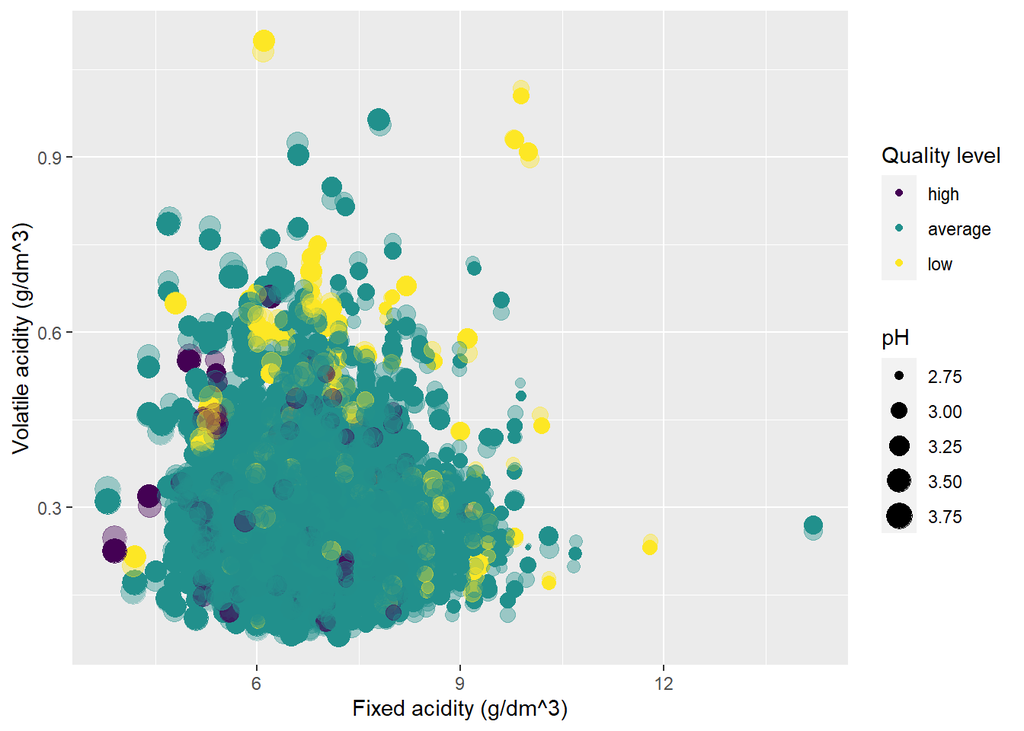

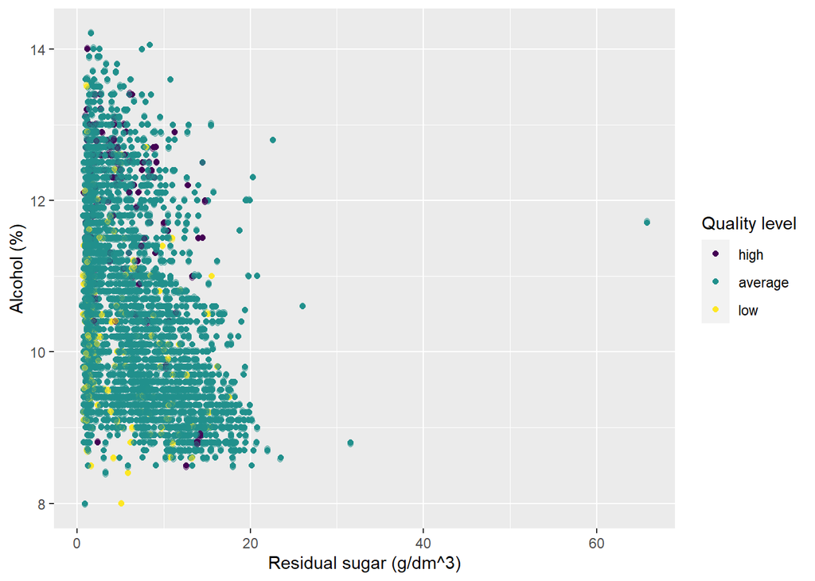

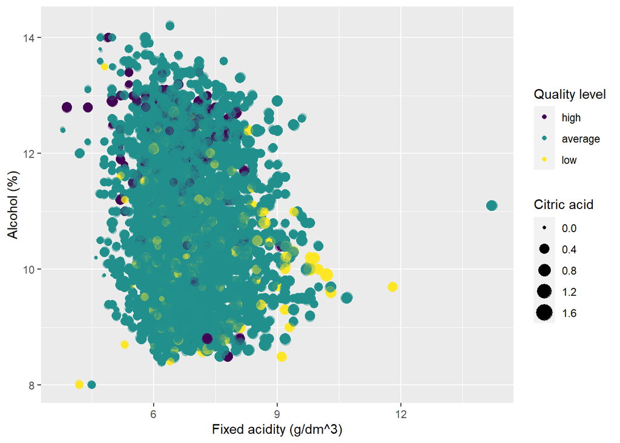

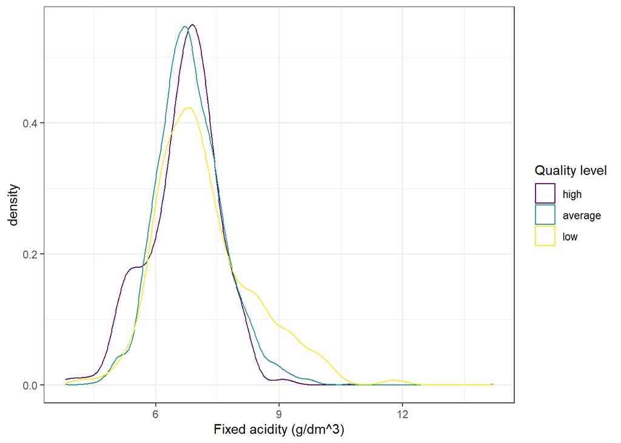

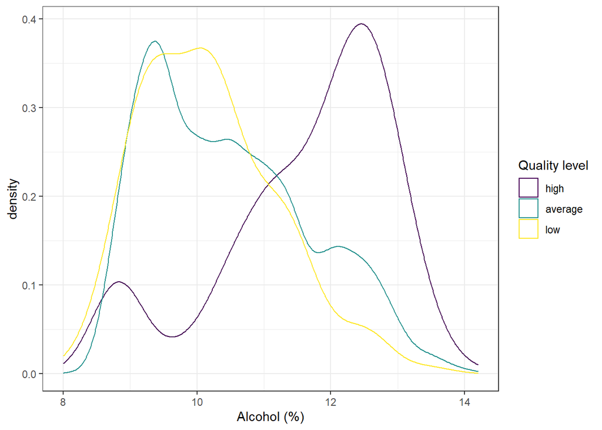

```
##
## Call:
## lm(formula = quality ~ alcohol, data = white_Wine_data)
##
## Residuals:
##     Min      1Q  Median      3Q     Max
## -3.5317 -0.5286  0.0012  0.4996  3.1579
##
## Coefficients:
##             Estimate Std. Error t value Pr(>|t|)
## (Intercept) 2.582009   0.098008   26.34   <2e-16 ***
## alcohol     0.313469   0.009258   33.86   <2e-16 ***
## ---
## Signif. codes:  0 '***' 0.001 '**' 0.01 '*' 0.05 '.' 0.1 ' ' 1
##
## Residual standard error: 0.7973 on 4896 degrees of freedom
## Multiple R-squared:  0.1897, Adjusted R-squared:  0.1896
## F-statistic:  1146 on 1 and 4896 DF,  p-value: < 2.2e-16
```

High quality wine density line is distinct from the others, and mostly distributed between 12 and 13.

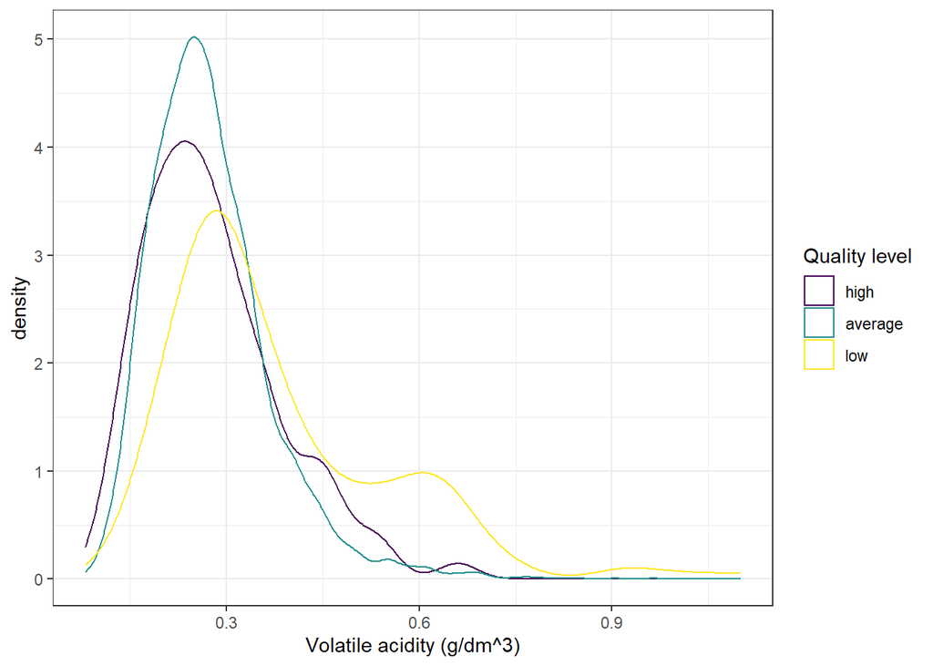

```
##
## Call:
## lm(formula = quality ~ volatile.acidity, data = white_Wine_data)
##
## Residuals:
##     Min      1Q  Median      3Q     Max
## -3.0631 -0.7894  0.0224  0.3133  3.2620
##
## Coefficients:
##                  Estimate Std. Error t value Pr(>|t|)
## (Intercept)       6.35397    0.03645  174.32   <2e-16 ***
## volatile.acidity -1.71095    0.12317  -13.89   <2e-16 ***
## ---
## Signif. codes:  0 '***' 0.001 '**' 0.01 '*' 0.05 '.' 0.1 ' ' 1
##
## Residual standard error: 0.8688 on 4896 degrees of freedom
## Multiple R-squared:  0.03792,    Adjusted R-squared:  0.03772
## F-statistic:   193 on 1 and 4896 DF,  p-value: < 2.2e-16
```

# Multivariate Analysis

### Were there any interesting or surprising interactions between features?

I feel like residual sugar should have an effect on the flavor but it had little impact on wine quality.

# Final Plots and Summary

### Plot One

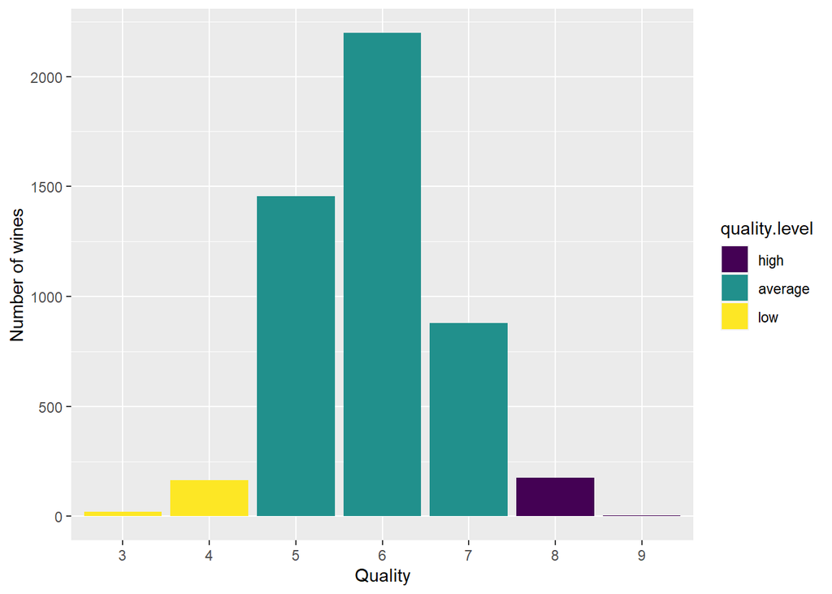

### Plot Two

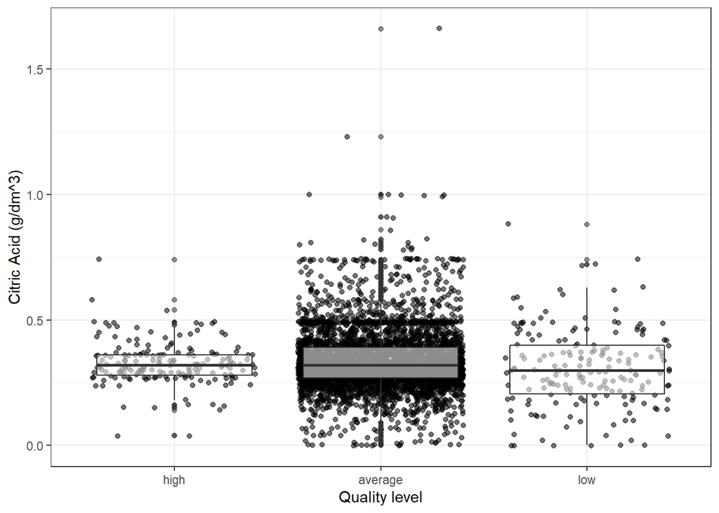

### Description Two

Citric Acid seems to have no correlation with quality. It is surprising that the average for all three quality levels appears to be the same. The acidity of a wine can greatly change the flavor but it did not seem to effect the results.

### Plot Three

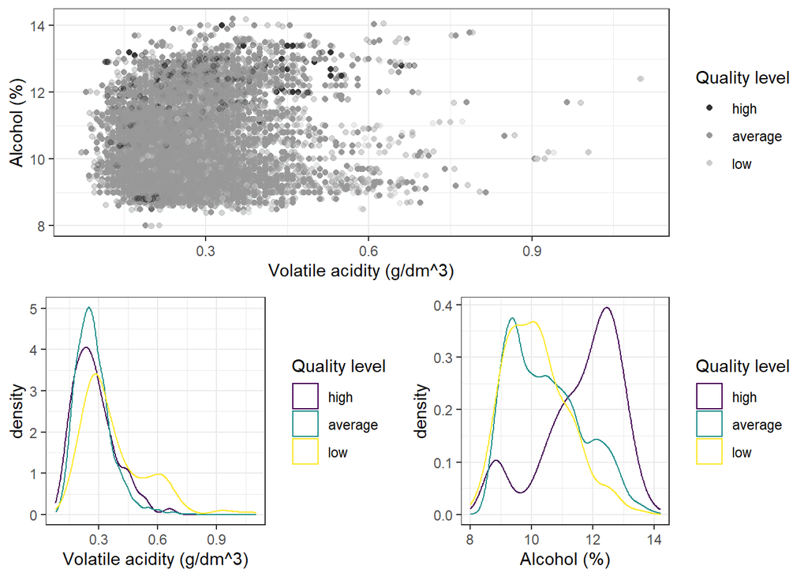

### Description Three

It appears that white wines that are rated higher have a higher alcohol content and lower volatile acidity. In conclusion alcohol and volatile acidity are an important factor in the quality of whie wines.

###Reflection

The white wines data set contains ratings on 4898 white wines. To understand the dataset I first graphed the provided data to find questions that I wanted to answer. After figuring out the questions I wanted to answer I created graphs to provide me with my answers.

There is a trend between the alcohol content and the quality of the wine. There is also a trend between the volatile acidity and the quality of the wine.